# FML Assignment 4

Roopali Aggarwal

2024-03-14

Instructions - An equities analyst is studying the pharmaceutical industry and would like your help in exploring and understanding the financial data collected by her firm. Her main objective is to understand the structure of the pharmaceutical industry using some basic financial measures. Use cluster analysis to explore and analyze the given dataset as follows:

```r
library(dplyr)
library(tidyverse)
library(caret)
library(factoextra)
library(flexclust)
```

```r
library(cluster)
library(ISLR)
library(ggplot2)
library(lattice)
library(dbscan)
library(knitr)
#Read the data using the working directory
pharma.data <- read.csv("/Applications/Pharmaceuticals.csv")
#Summary of the data, showing dimensions and structure
summary(pharma.data)
```

```
##     Symbol              Name             Market_Cap          Beta
##  Length:21          Length:21          Min.   :  0.41   Min.   :0.1800
##  Class :character   Class :character   1st Qu.:  6.30   1st Qu.:0.3500
##  Mode  :character   Mode  :character   Median : 48.19   Median :0.4600
##                                        Mean   : 57.65   Mean   :0.5257
##                                        3rd Qu.: 73.84   3rd Qu.:0.6500
##                                        Max.   :199.47   Max.   :1.1100
##     PE_Ratio          ROE            ROA        Asset_Turnover    Leverage
##  Min.   : 3.60   Min.   : 3.9   Min.   : 1.40   Min.   :0.3    Min.   :0.0000
##  1st Qu.:18.90   1st Qu.:14.9   1st Qu.: 5.70   1st Qu.:0.6    1st Qu.:0.1600
##  Median :21.50   Median :22.6   Median :11.20   Median :0.6    Median :0.3400
##  Mean   :25.46   Mean   :25.8   Mean   :10.51   Mean   :0.7    Mean   :0.5857
##  3rd Qu.:27.90   3rd Qu.:31.0   3rd Qu.:15.00   3rd Qu.:0.9    3rd Qu.:0.6000
##  Max.   :82.50   Max.   :62.9   Max.   :20.30   Max.   :1.1    Max.   :3.5100
##    Rev_Growth    Net_Profit_Margin Median_Recommendation   Location
##  Min.   :-3.17   Min.   : 2.6      Length:21             Length:21
##  1st Qu.: 6.38   1st Qu.:11.2      Class :character      Class :character
##  Median : 9.37   Median :16.1      Mode  :character      Mode  :character
##  Mean   :13.37   Mean   :15.7
##  3rd Qu.:21.87   3rd Qu.:21.1
##  Max.   :34.21   Max.   :25.5
##    Exchange
##  Length:21
##  Class :character
##  Mode  :character
##
##
##
```

```r
dim(pharma.data)
```

```
## [1] 21 14
```

```r
str(pharma.data)
```

```
## 'data.frame':    21 obs. of  14 variables:
##  $ Symbol               : chr  "ABT" "AGN" "AHM" "AZN" ...
##  $ Name                 : chr  "Abbott Laboratories" "Allergan, Inc." "Amersham plc" "AstraZeneca PLC" ...
##  $ Market_Cap           : num  68.44 7.58 6.3 67.63 47.16 ...
##  $ Beta                 : num  0.32 0.41 0.46 0.52 0.32 1.11 0.5 0.85 1.08 0.18 ...
##  $ PE_Ratio             : num  24.7 82.5 20.7 21.5 20.1 27.9 13.9 26 3.6 27.9 ...
##  $ ROE                  : num  26.4 12.9 14.9 27.4 21.8 3.9 34.8 24.1 15.1 31 ...
##  $ ROA                  : num  11.8 5.5 7.8 15.4 7.5 1.4 15.1 4.3 5.1 13.5 ...
##  $ Asset_Turnover       : num  0.7 0.9 0.9 0.9 0.6 0.6 0.9 0.6 0.3 0.6 ...
##  $ Leverage             : num  0.42 0.6 0.27 0 0.34 0 0.57 3.51 1.07 0.53 ...
##  $ Rev_Growth           : num  7.54 9.16 7.05 15 26.81 ...
##  $ Net_Profit_Margin    : num  16.1 5.5 11.2 18 12.9 2.6 20.6 7.5 13.3 23.4 ...
##  $ Median_Recommendation: chr  "Moderate Buy" "Moderate Buy" "Strong Buy" "Moderate Sell" ...
##  $ Location             : chr  "US" "CANADA" "UK" "UK" ...
##  $ Exchange             : chr  "NYSE" "NYSE" "NYSE" "NYSE" ...
```

Qa.Use only the numerical variables (1 to 9) to cluster the 21 firms. Justify the various choices made in conducting the cluster analysis, such as weights for different variables, the specific clustering algorithm(s) used, the number of clusters formed, and so on.

```r
#Removing rows with missing values
data <- na.omit(pharma.data)
#Extracting only the numerical variables
num.data <- data[, c(3:11)]
num.data
```

```
##    Market_Cap Beta PE_Ratio  ROE  ROA Asset_Turnover Leverage Rev_Growth
## 1       68.44 0.32     24.7 26.4 11.8            0.7     0.42       7.54
## 2        7.58 0.41     82.5 12.9  5.5            0.9     0.60       9.16
## 3        6.30 0.46     20.7 14.9  7.8            0.9     0.27       7.05
## 4       67.63 0.52     21.5 27.4 15.4            0.9     0.00      15.00
## 5       47.16 0.32     20.1 21.8  7.5            0.6     0.34      26.81
## 6       16.90 1.11     27.9  3.9  1.4            0.6     0.00      -3.17
## 7       51.33 0.50     13.9 34.8 15.1            0.9     0.57       2.70
## 8        0.41 0.85     26.0 24.1  4.3            0.6     3.51       6.38
## 9        0.78 1.08      3.6 15.1  5.1            0.3     1.07      34.21
## 10      73.84 0.18     27.9 31.0 13.5            0.6     0.53       6.21
## 11     122.11 0.35     18.0 62.9 20.3            1.0     0.34      21.87
## 12       2.60 0.65     19.9 21.4  6.8            0.6     1.45      13.99
## 13     173.93 0.46     28.4 28.6 16.3            0.9     0.10       9.37
## 14       1.20 0.75     28.6 11.2  5.4            0.3     0.93      30.37
```

[output cut: 29 more lines]

```r
#Standardizing the dataset
data.norm <- preProcess(num.data , method = c("center", "scale"))
pharma.norm = predict(data.norm , num.data)
pharma.norm
```

```
##    Market_Cap        Beta    PE_Ratio         ROE        ROA Asset_Turnover
## 1   0.1840960 -0.80125356 -0.04671323  0.04009035  0.2416121      0.0000000
## 2  -0.8544181 -0.45070513  3.49706911 -0.85483986 -0.9422871      0.9225312
## 3  -0.8762600 -0.25595600 -0.29195768 -0.72225761 -0.5100700      0.9225312
## 4   0.1702742 -0.02225704 -0.24290879  0.10638147  0.9181259      0.9225312
## 5  -0.1790256 -0.80125356 -0.32874435 -0.26484883 -0.5664461     -0.4612656
## 6  -0.6953818  2.27578267  0.14948233 -1.45146000 -1.7127612     -0.4612656
## 7  -0.1078688 -0.10015669 -0.70887325  0.59693581  0.8617498      0.9225312
## 8  -0.9767669  1.26308721  0.03299122 -0.11237924 -1.1677918     -0.4612656
## 9  -0.9704532  2.15893320 -1.34037772 -0.70899938 -1.0174553     -1.8450624
## 10  0.2762415 -1.34655112  0.14948233  0.34502953  0.5610770     -0.4612656
## 11  1.0999201 -0.68440408 -0.45749769  2.45971647  1.8389364      1.3837968
## 12 -0.9393967  0.48409069 -0.34100657 -0.29136529 -0.6979905     -0.4612656
## 13  1.9841758 -0.25595600  0.18013789  0.18593083  1.0872544      0.9225312
## 14 -0.9632863  0.87358895  0.19240011 -0.96753478 -0.9610792     -1.8450624
```

[output cut: 29 more lines]

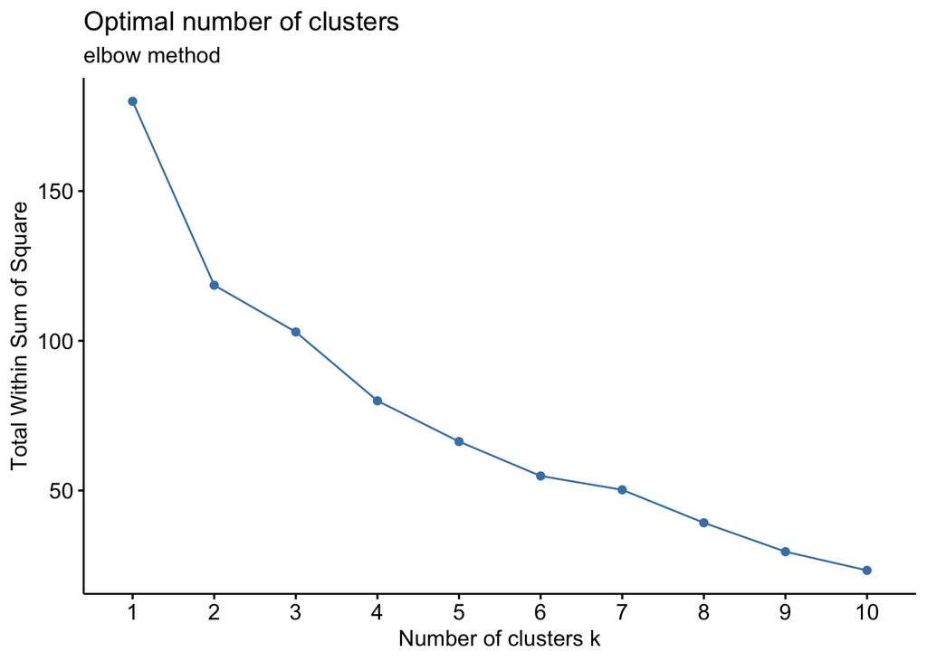

```r
#Finding the value of k using elbow and silhouette method
fviz_nbclust(pharma.norm , kmeans , method = "wss") + labs(subtitle = "elbow method")
```

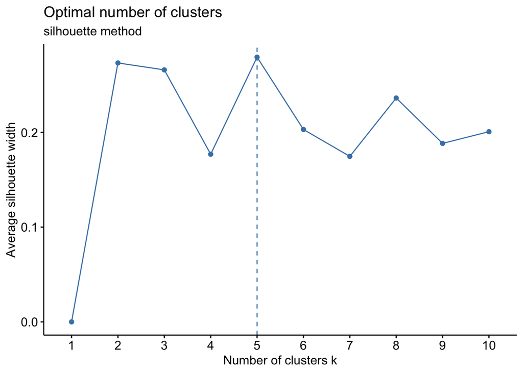

```r
fviz_nbclust(pharma.norm , kmeans , method = "silhouette") + labs(subtitle = "silhouette method")
```

```r
#creating clusters using kmeans
set.seed(600)
cluster <- kmeans(pharma.norm, centers = 5)
cluster
```

```
## K-means clustering with 5 clusters of sizes 4, 7, 3, 3, 4
##
## Cluster means:
##    Market_Cap       Beta   PE_Ratio        ROE        ROA Asset_Turnover
## 1 -0.96247577  1.1949250 -0.3639982 -0.5200697 -0.9610792  -1.153164e+00
## 2  0.08926902 -0.4618336 -0.3208615  0.3260892  0.5396003   6.589509e-02
## 3 -0.66114002 -0.7233539 -0.3512251 -0.6736441 -0.5915022  -1.537552e-01
## 4 -0.52462814  0.4451409  1.8498439 -1.0404550 -1.1865838   1.480297e-16
## 5  1.69558112 -0.1780563 -0.1984582  1.2349879  1.3503431   1.153164e+00
##     Leverage Rev_Growth Net_Profit_Margin
## 1  1.4773718  0.7120120        -0.3688236
## 2 -0.2559803 -0.7230135         0.7343816
## 3 -0.4040831  0.6917224        -0.4005718
## 4 -0.3443544 -0.5769454        -1.6095439
## 5 -0.4680782  0.4671788         0.5912425
##
## Clustering vector:
##  1  2  3  4  5  6  7  8  9 10 11 12 13 14 15 16 17 18 19 20 21
##  2  4  3  2  3  4  2  1  1  2  5  1  5  1  5  2  5  4  2  3  2
##
## Within cluster sum of squares by cluster:
## [1] 19.219788 16.655937  5.511294 14.938904  9.284424
##  (between_SS / total_SS =  63.5 %)
##
## Available components:
##
## [1] "cluster"      "centers"      "totss"        "withinss"     "tot.withinss"
## [6] "betweenss"    "size"         "iter"         "ifault"
```

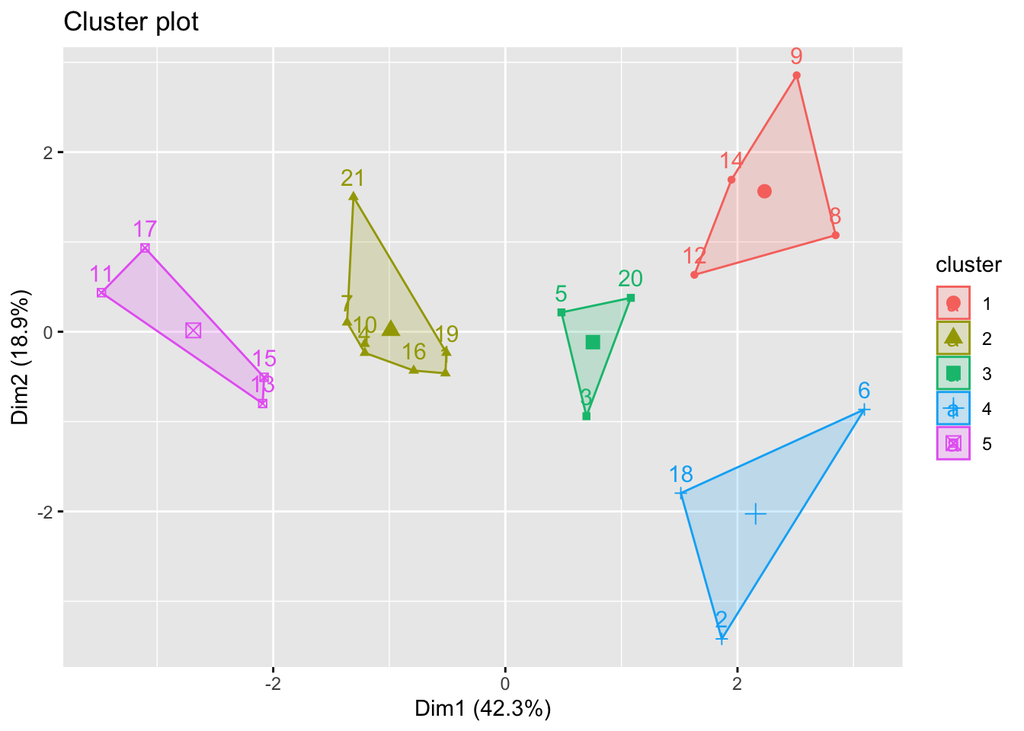

```r
fviz_cluster(cluster , data = pharma.norm)
```

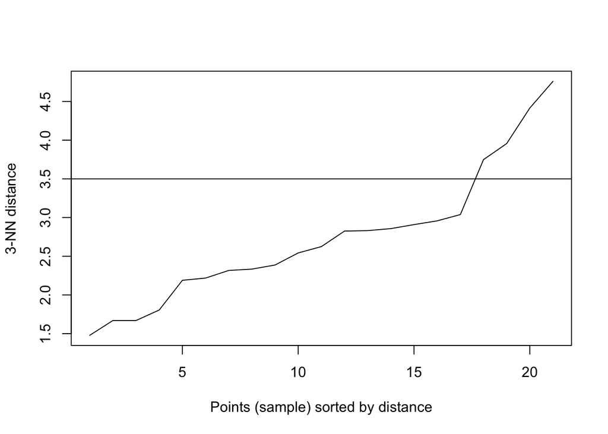

```r
#creating clusters using dbscan
# finding the optimal value of eps
dbscan::kNNdistplot(pharma.norm , k=3)
abline(h = 3.5)
```

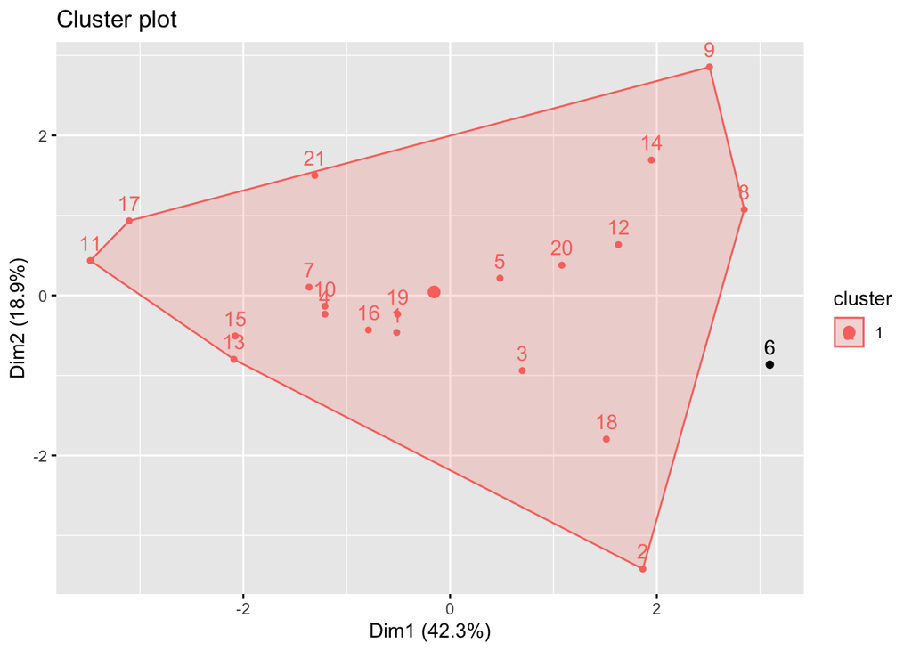

```r
pharma.db <- dbscan::dbscan(pharma.norm , eps = 3.5 , minPts = 3)
fviz_cluster(pharma.db , pharma.norm)
```

```r
#creating clusters using hierarchical method
pharma.single <- agnes(pharma.norm , method = "single")
pharma.complete <- agnes(pharma.norm , method = "complete")
pharma.average <- agnes(pharma.norm , method = "average")
pharma.single
```

```
## Call:     agnes(x = pharma.norm, method = "single")
## Agglomerative coefficient:  0.4600348
## Order of objects:
##  [1] 1  4  19 10 7  16 3  13 15 5  20 11 21 12 17 9  14 2  18 8  6
## Height (summary):
##    Min. 1st Qu.  Median    Mean 3rd Qu.    Max.
##   1.081   1.553   2.165   2.081   2.404   3.636
##
## Available components:
## [1] "order"     "height"    "ac"        "merge"     "diss"      "call"
## [7] "method"    "order.lab" "data"
```

```r
pharma.complete
```

```
## Call:     agnes(x = pharma.norm, method = "complete")
## Agglomerative coefficient:  0.6990833
## Order of objects:
##  [1] 1  10 16 21 4  19 7  13 15 11 17 2  18 6  3  12 5  20 9  14 8
## Height (summary):
##    Min. 1st Qu.  Median    Mean 3rd Qu.    Max.
##   1.081   1.896   2.579   3.294   4.718   7.546
##
## Available components:
## [1] "order"     "height"    "ac"        "merge"     "diss"      "call"
## [7] "method"    "order.lab" "data"
```

```r
pharma.average
```

```
## Call:     agnes(x = pharma.norm, method = "average")
## Agglomerative coefficient:  0.5600652
## Order of objects:
##  [1] 1  10 16 3  4  19 7  5  20 12 21 11 17 13 15 2  18 6  8  9  14
## Height (summary):
##    Min. 1st Qu.  Median    Mean 3rd Qu.    Max.
##   1.081   1.798   2.418   2.765   3.573   5.023
##
## Available components:
## [1] "order"     "height"    "ac"        "merge"     "diss"      "call"
## [7] "method"    "order.lab" "data"
```

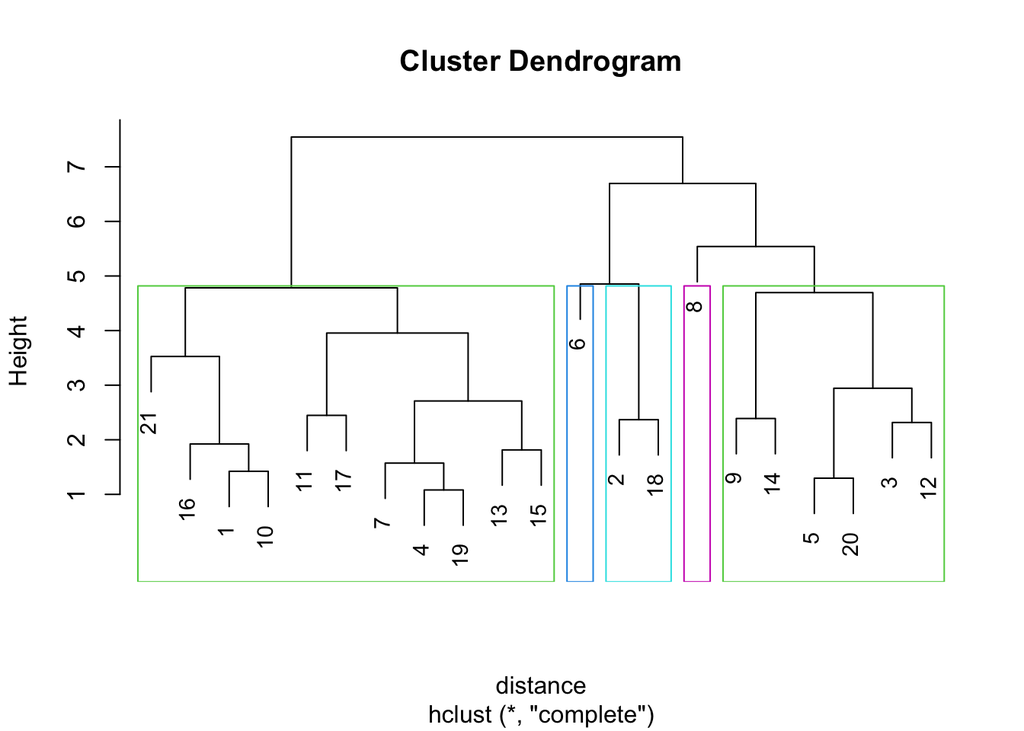

```r
#Using pharma.complete since it has highest agglomerative function
distance <- dist(pharma.norm , method = "euclidean")
pharma.complete.2 <- hclust(distance, method = "complete")
plot(pharma.complete.2 , cex = 0.9)
rect.hclust(pharma.complete.2 , k=5 , border=3:6)
```

The cluster analysis decisions were carefully thought out to make sure we get good insights from the data. First, the data was normalized by putting them on the same scale. Then, we explored three clustering methods - k-means, DBSCAN, and hierarchical clustering. We found that k-means split the data into 5 clear clusters, DBSCAN just squished everything into 1 cluster with 1 outlier and hierarchical clustering has 2 outliers showing potential limitations. Given the dataset’s financial nature, we decided to stick with k-means because it seemed to show the data’s patterns better. Unlike DBSCAN and hierarchical clustering, which exhibited outliers, k-means revealed a more cohesive clustering pattern without significant outliers.

Qb.Interpret the clusters with respect to the numerical variables used in forming the clusters.

```r
#Viewing the data points in order to interpret the 5 clusters created using kmeans method
cluster1 <- kable(pharma.norm[c(12,14,9,8),], align = "c")
cluster1
```

|  | Market_Cap | Beta | PE_Ratio | ROE | ROA | Asset_Turnover | Leverage | Rev_Growth | Net_Profit_Margin |
| --- | --- | --- | --- | --- | --- | --- | --- | --- | --- |
| 12 | -0.9393967 | 0.4840907 | -0.3410066 | -0.2913653 | -0.6979905 | -0.4612656 | 1.1062004 | 0.0560309 | -0.7155141 |
| 14 | -0.9632863 | 0.8735889 | 0.1924001 | -0.9675348 | -0.9610792 | -1.8450624 | 0.4406517 | 1.5386072 | 0.8541178 |
| 9 | -0.9704532 | 2.1589332 | -1.3403777 | -0.7089994 | -1.0174553 | -1.8450624 | 0.6198379 | 1.8861708 | -0.3650138 |
| 8 | -0.9767669 | 1.2630872 | 0.0329912 | -0.1123792 | -1.1677918 | -0.4612656 | 3.7427970 | -0.6327607 | -1.2488842 |

```r
cluster2 <- kable(pharma.norm[c(21,7,10,4,16,1,19),], align = "c")
cluster2
```

|  | Market_Cap | Beta | PE_Ratio | ROE | ROA | Asset_Turnover | Leverage | Rev_Growth | Net_Profit_Margin |
| --- | --- | --- | --- | --- | --- | --- | --- | --- | --- |
| 21 | -0.1614497 | 0.4061910 | -0.7579221 | 1.9293875 | 0.5422849 | -0.4612656 | 0.6838330 | -1.1776392 | 1.4941618 |
| 7 | -0.1078688 | -0.1001567 | -0.7088733 | 0.5969358 | 0.8617498 | 0.9225312 | -0.0201127 | -0.9658426 | 0.7474438 |
| 10 | 0.2762415 | -1.3465511 | 0.1494823 | 0.3450295 | 0.5610770 | -0.4612656 | -0.0713088 | -0.6481476 | 1.1741398 |
| 4 | 0.1702742 | -0.0222570 | -0.2429088 | 0.1063815 | 0.9181259 | 0.9225312 | -0.7496565 | 0.1474473 | 0.3512260 |
| 16 | 0.6654710 | -1.3076013 | -0.2367777 | -0.5233842 | 0.1288598 | -0.9225312 | -0.6728624 | -1.4536989 | 1.0217484 |
| 1 | 0.1840960 | -0.8012536 | -0.0467132 | 0.0400903 | 0.2416121 | 0.0000000 | -0.2120979 | -0.5277675 | 0.0616823 |
| 19 | -0.4018812 | -0.0612069 | -0.4023177 | -0.2118159 | 0.5234929 | 0.4612656 | -0.7496565 | -0.4354459 | 0.2902694 |

Firms in Cluster 2 represents a diverse mix of financial characteristics among the included firms. While many exhibit positive returns on equity (ROE) and assets (ROA), indicative of profitability and operational efficiency, there are also companies facing challenges such as negative revenue growth. Net profit margin varies, with all firms exhibiting positive margins, indicating profitability across the cluster.

```r
cluster3 <- kable(pharma.norm[c(5,20,3),], align = "c")
cluster3
```

|  | Market_Cap | Beta | PE_Ratio | ROE | ROA | Asset_Turnover | Leverage | Rev_Growth | Net_Profit_Margin |
| --- | --- | --- | --- | --- | --- | --- | --- | --- | --- |
| 5 | -0.1790256 | -0.8012536 | -0.3287443 | -0.2648488 | -0.5664461 | -0.4612656 | -0.3144900 | 1.2163867 | -0.4259704 |
| 20 | -0.9281345 | -1.1128522 | -0.4329732 | -1.0338259 | -0.6979905 | -0.9225312 | -0.4936762 | 1.4308986 | -0.0907092 |
| 3 | -0.8762600 | -0.2559560 | -0.2919577 | -0.7222576 | -0.5100700 | 0.9225312 | -0.4040831 | -0.5721181 | -0.6850358 |

Firms in Cluster 3 exhibit characteristics of relatively small market capitalization, moderate to low volatility (as indicated by moderate to low beta), moderate to low valuation (as indicated by moderate to low PE ratio), negative ROE and ROA, average asset turnover, lower leverage, and varying levels of profitability. Notably, they show high revenue growth, indicating strong sales performance despite moderate profitability.

```r
cluster4 <- kable(pharma.norm[c(18,6,2),], align = "c")
cluster4
```

|  | Market_Cap | Beta | PE_Ratio | ROE | ROA | Asset_Turnover | Leverage | Rev_Growth | Net_Profit_Margin |
| --- | --- | --- | --- | --- | --- | --- | --- | --- | --- |
| 18 | -0.0240846 | -0.4896550 | 1.9029802 | -0.8150652 | -0.9047030 | -0.4612656 | -0.3016910 | 0.1474473 | -1.279362 |
| 6 | -0.6953818 | 2.2757827 | 0.1494823 | -1.4514600 | -1.7127612 | -0.4612656 | -0.7496565 | -1.4971443 | -1.995602 |
| 2 | -0.8544181 | -0.4507051 | 3.4970691 | -0.8548399 | -0.9422871 | 0.9225312 | 0.0182843 | -0.3811391 | -1.553667 |

```r
cluster5 <- kable(pharma.norm[c(11,17,13,15),], align = "c")
cluster5
```

|  | Market_Cap | Beta | PE_Ratio | ROE | ROA | Asset_Turnover | Leverage | Rev_Growth | Net_Profit_Margin |
| --- | --- | --- | --- | --- | --- | --- | --- | --- | --- |
| 11 | 1.099920 | -0.6844041 | -0.4574977 | 2.4597165 | 1.8389364 | 1.3837968 | -0.3144900 | 0.7692605 | 0.8236395 |
| 17 | 2.419990 | 0.4840907 | -0.1141555 | 1.3128800 | 1.6322239 | 0.4612656 | -0.5448723 | 1.1014372 | 1.4484444 |
| 13 | 1.984176 | -0.2559560 | 0.1801379 | 0.1859308 | 1.0872544 | 0.9225312 | -0.6216663 | -0.3621317 | 0.3359869 |
| 15 | 1.278239 | -0.2559560 | -0.4023177 | 0.9814243 | 0.8429577 | 1.8450624 | -0.3912841 | 0.3601491 | -0.2431006 |

Firms in cluster 5 comprises firms with strong financial performance, characterized by high profitability metrics such as ROE and ROA, along with positive net profit margins. The cluster also demonstrates efficient asset utilization and relatively high market capitalization, indicating robust financial health among the included firms.

Qc. Is there a pattern in the clusters with respect to the numerical variables (10 to 12)

```r
#Identifying the patter of remaining variables
kcluster <- cluster$cluster
Pattern <- pharma.data %>%
  select(c(1,2,12,13,14)) %>%
  mutate(Cluster = kcluster)
Pattern
```

```
##    Symbol                               Name Median_Recommendation    Location
## 1     ABT                Abbott Laboratories          Moderate Buy          US
## 2     AGN                     Allergan, Inc.          Moderate Buy      CANADA
## 3     AHM                       Amersham plc            Strong Buy          UK
## 4     AZN                    AstraZeneca PLC         Moderate Sell          UK
## 5     AVE                            Aventis          Moderate Buy      FRANCE
## 6     BAY                           Bayer AG                  Hold     GERMANY
## 7     BMY       Bristol-Myers Squibb Company         Moderate Sell          US
## 8    CHTT                       Chattem, Inc          Moderate Buy          US
## 9     ELN              Elan Corporation, plc         Moderate Sell     IRELAND
## 10    LLY              Eli Lilly and Company                  Hold          US
## 11    GSK                GlaxoSmithKline plc                  Hold          UK
## 12    IVX                   IVAX Corporation                  Hold          US
## 13    JNJ                  Johnson & Johnson          Moderate Buy          US
## 14    MRX Medicis Pharmaceutical Corporation          Moderate Buy          US
```

[output cut: 29 more lines]

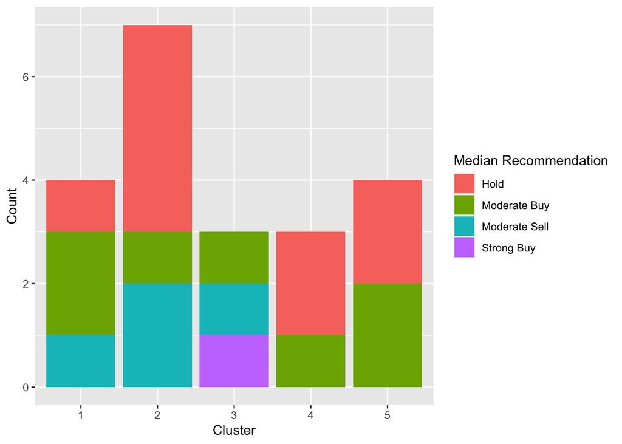

```r
#Plotting the data points to find the pattern
ggplot(Pattern, aes(x = factor(Cluster), fill = Median_Recommendation)) +
  geom_bar() + labs(x = "Cluster", y = "Count", fill = "Median Recommendation")
```

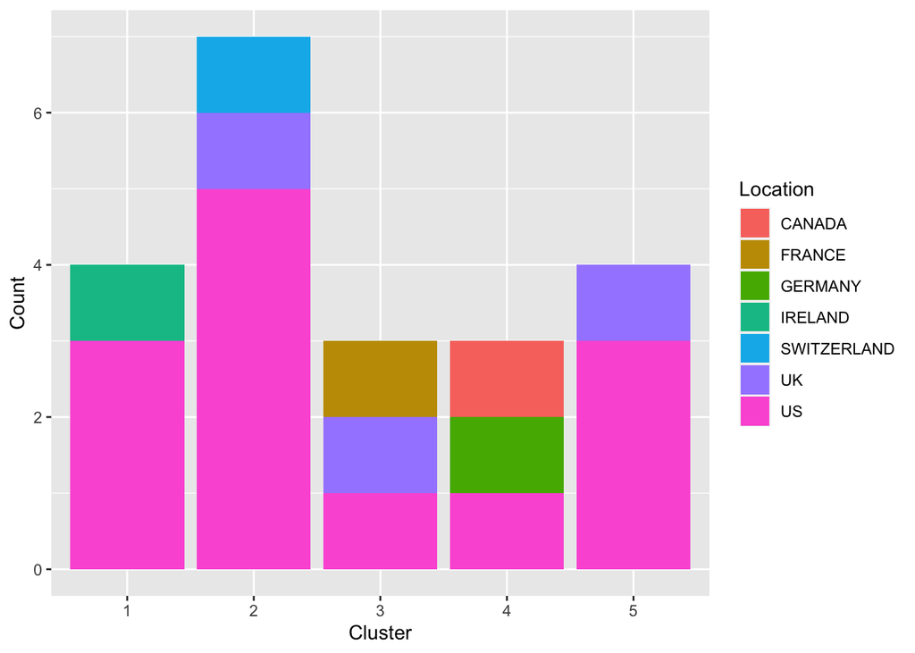

```r
ggplot(Pattern, aes(x = factor(Cluster), fill = Location)) +
  geom_bar() + labs(x = "Cluster", y = "Count", fill = "Location")
```

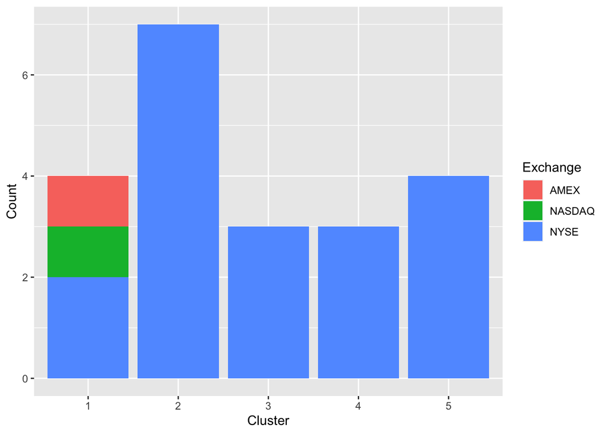

```r
ggplot(Pattern, aes(x = factor(Cluster), fill = Exchange)) +
  geom_bar() + labs(x = "Cluster", y = "Count", fill = "Exchange")
```

Graph 2 (Location by Cluster): Observations: Companies in Cluster 1, 2, and 5 are primarily located in the United States. Cluster 3 includes companies from the United States, the United Kingdom, and France. Cluster 4 comprises companies from the United States, Germany, and Canada.

Now linking the Graphs to see a pattern:

Cluster 1: Predominantly receives “Moderate buy” recommendations, primarily consists of companies from the United States, and is listed on multiple exchanges. Cluster 2: Receives “Hold” recommendations, with companies primarily from the United States, UK, and Switzerland, and listed predominantly on NYSE. Cluster 3: Stands out with “Strong Buy” and “Moderate Buy” recommendations, includes companies from the United States, UK, and France, and is listed only on NYSE. Cluster 4: Receives “Hold” recommendations, includes companies from the United States, Germany, and Canada, and is listed predominantly on NYSE. Cluster 5: Equally receives “Hold and Moderate buy” recommendations, consists of companies from the United States and UK, and is listed predominantly on NYSE.

This analysis provides a understanding of the clustering patterns, considering financial recommendations, geographical locations, and stock exchange listings. It helps identify distinct characteristics and trends within each cluster, aiding in decision-making processes such as investment strategies or industry analysis.

Qd. Provide an appropriate name for each cluster using any or all of the variables in the dataset.

Cluster2 - Mixed Performance Enterprises Firms in this cluster exhibit a mix of financial characteristics, including positive returns on equity and assets alongside challenges such as negative revenue growth. The cluster demonstrates a spectrum of financial performance, reflecting a blend of strengths and weaknesses across included companies.

Cluster3 - Growth Potential Innovators Companies in Cluster 3 display characteristics of relatively small market capitalization and moderate financial metrics. Despite facing challenges such as negative ROE and ROA, these firms show resilience with high revenue growth, indicating steady growth potential despite moderate profitability.

Cluster5 - Financial Powerhouses Cluster 5 comprises firms demonstrating strong financial performance, characterized by high profitability metrics such as ROE and ROA, positive net profit margins, and efficient asset utilization. The cluster represents industry leaders with robust financial health and performance, poised for continued success and leadership in the market.